# Unsupervised machine learning

## Topic Modeling: Structural Topic Model

Most text corpora have not only the documents per se, but also a lot of metadata associated – we know the author, characteristics of the author, when the document was produced, etc. The structural topic model takes advantage of this metadata to improve the discovery of topics. Here we will learn how it works, how we can interpret the output, and some issues related to its usage for research.

We will continue with the previous example, but now adding one covariate: the party of the president.

```r
library(stm)
# extracting covariates
year <- as.numeric(substr(nyt$datetime, 1, 4))
repub <- ifelse(year %in% c(1981:1992, 2000:2008), 1, 0)
```

And now we’re ready to run `stm`!

```r
# running STM
stm <- stm(documents=cdfm, K=30, prevalence=~repub, max.em.its=100)
```

```
## Beginning Spectral Initialization
##   Calculating the gram matrix...
##   Using only 10000 most frequent terms during initialization...
##   Finding anchor words...
##      ..............................
##   Recovering initialization...
##      ....................................................................................................
## Initialization complete.
## ....................................................................................................
## Completed E-Step (3 seconds).
## Completed M-Step.
## Completing Iteration 1 (approx. per word bound = -7.823)
## ....................................................................................................
## Completed E-Step (3 seconds).
## Completed M-Step.
## Completing Iteration 2 (approx. per word bound = -7.286, relative change = 6.856e-02)
## ....................................................................................................
## Completed E-Step (3 seconds).
## Completed M-Step.
## Completing Iteration 3 (approx. per word bound = -7.233, relative change = 7.307e-03)
## ....................................................................................................
## Completed E-Step (3 seconds).
## Completed M-Step.
## Completing Iteration 4 (approx. per word bound = -7.217, relative change = 2.164e-03)
## ....................................................................................................
## Completed E-Step (3 seconds).
## Completed M-Step.
## Completing Iteration 5 (approx. per word bound = -7.210, relative change = 1.044e-03)
## Topic 1: bill, senate, house, d, stimulus
##  Topic 2: billion, deficit, budget, trade, year
##  Topic 3: federal, rates, interest, reserve, fed
##  Topic 4: even, way, make, people, day
##  Topic 5: president, mr, obama, bush, economy
##  Topic 6: prices, dollar, oil, yesterday, new
##  Topic 7: street, wall, financial, many, money
##  Topic 8: said, new, prime, long, minister
##  Topic 9: one, editor, us, can, america's
##  Topic 10: corporate, year, companies, america, last
##  Topic 11: economic, president, company, said, none
##  Topic 12: percent, prices, said, rose, last
```

[output cut: 811 more lines]

```
##  Topic 24: president, mr, economic, reagan, administration
##  Topic 25: unemployment, jobs, workers, labor, percent
##  Topic 26: can, economic, people, like, much
##  Topic 27: states, united, world, american, economic
##  Topic 28: health, care, social, education, national
##  Topic 29: percent, sales, department, said, reported
##  Topic 30: week, lead, million, year, last
## ....................................................................................................
## Completed E-Step (2 seconds).
## Completed M-Step.
## Completing Iteration 86 (approx. per word bound = -7.175, relative change = 1.023e-05)
## ....................................................................................................
## Completed E-Step (2 seconds).
## Completed M-Step.
## Model Converged
```

```r
save(stm, file="../backup/stm-output.Rdata")
```

`stm` offers a series of features to explore the output. First, just like LDA, we can look at the words that are most associated with each topic.

```r
load("../backup/stm-output.Rdata")
# looking at a few topics
labelTopics(stm, topics=1)
```

```
## Topic 1 Top Words:
##       Highest Prob: tax, house, congress, bill, senate, president, plan
##       FREX: y, senate, bill, package, stimulus, tax, republicans
##       Lift: ackerman, gingrich's, boren, moynihan, newt, reid, y
##       Score: y, tax, senate, democrats, republicans, bill, congress
```

```r
labelTopics(stm, topics=4)
```

```
## Topic 4 Top Words:
##       Highest Prob: even, people, way, day, new, like, lot
##       FREX: park, friend, tables, lot, death, ms, always
##       Lift: aspect, bedford, brand-new, condos, hyde, installed, jeep
##       Score: park, lot, starbucks, lake, young, death, ms
```

```r
labelTopics(stm, topics=5)
```

```
## Topic 5 Top Words:
##       Highest Prob: president, mr, bush, obama, campaign, economy, republican
##       FREX: romney, kerry, election, presidential, campaign, voters, obama
##       Lift: adversaries, advocacy, audacious, bachmann, beirut, big-spending, boasts
##       Score: obama, voters, republican, bush, democrats, senator, campaign
```

```r
labelTopics(stm, topics=7)
```

```
## Topic 7 Top Words:
##       Highest Prob: street, wall, financial, money, treasury, paulson, plan
##       FREX: street, paulson, goldman, wall, sachs, henry, rescue
##       Lift: aviation, hobbled, lehman's, backstop, bondholders, disliked, likewise
##       Score: wall, street, paulson, goldman, sachs, bailout, henry
```

```r
labelTopics(stm, topics=9)
```

```
## Topic 9 Top Words:
##       Highest Prob: one, editor, us, column, op-ed, money, like
##       FREX: column, op-ed, re, editor, aug, us, generation
##       Lift: 19th-century, admonitions, arisen, austere, backs, brooks, burn
##       Score: editor, op-ed, column, re, us, krugman, galbraith
```

But unlike LDA, we now can estimate the effects of the features we considered into the prevalence of different topics

```r
# effects
est <- estimateEffect(~repub, stm,
    uncertainty="None")
summary(est, topics=1)
```

[output not shown]

```r
summary(est, topics=4)
```

[output not shown]

```r
summary(est, topics=5)
```

[output not shown]

```r
summary(est, topics=7)
```

[output not shown]

```r
summary(est, topics=9)
```

[output not shown]

Let’s say we’re interested in finding the most partisan topics. How would we do this?

```r
# let's look at the structure of the output object...
names(est)
```

```
## [1] "parameters"  "topics"      "call"        "uncertainty" "formula"
## [6] "data"        "modelframe"  "varlist"
```

```r
length(est$parameters)
```

```
## [1] 30
```

```r
est$parameters[[1]]
```

```
## [[1]]
## [[1]]$est
## (Intercept)       repub
##  0.05431745 -0.02605660
##
## [[1]]$vcov
##               [,1]          [,2]
## [1,]  6.882598e-06 -6.882598e-06
## [2,] -6.882598e-06  1.058536e-05
```

```r
# aha! we'll just extract the coefficients for each topic
coef <- se <- rep(NA, 30)
for (i in 1:30){
    coef[i] <- est$parameters[[i]][[1]]$est[2]
    se[i] <- sqrt(est$parameters[[i]][[1]]$vcov[2,2])
}

df <- data.frame(topic = 1:30, coef=coef, se=se)
df <- df[order(df$coef),] # sorting by "partisanship"
head(df[order(df$coef),])
```

```
##    topic        coef          se
## 1      1 -0.02605660 0.003253514
## 25    25 -0.01984025 0.003217467
## 4      4 -0.01932438 0.003585274
## 5      5 -0.01674535 0.004176024
## 26    26 -0.01529345 0.002361583
## 22    22 -0.01330527 0.003146045
```

```r
tail(df[order(df$coef),])
```

```
##    topic        coef          se
## 29    29 0.008094138 0.004829440
## 11    11 0.009420292 0.002704950
## 30    30 0.015715169 0.001280006
## 16    16 0.017828492 0.002750289
## 23    23 0.024470820 0.003255611
## 24    24 0.024503662 0.003501498
```

```r
# three most "democratic" topics
labelTopics(stm, topics=df$topic[1])
```

```
## Topic 1 Top Words:
##       Highest Prob: tax, house, congress, bill, senate, president, plan
##       FREX: y, senate, bill, package, stimulus, tax, republicans
##       Lift: ackerman, gingrich's, boren, moynihan, newt, reid, y
##       Score: y, tax, senate, democrats, republicans, bill, congress
```

```r
labelTopics(stm, topics=df$topic[2])
```

```
## Topic 25 Top Words:
##       Highest Prob: unemployment, jobs, workers, labor, percent, americans, job
##       FREX: unemployment, jobs, census, bureau, workers, poverty, employment
##       Lift: snail's, staple, 11.7, 18,000, 2007-9, 247,000, 39,000
##       Score: jobs, unemployment, poverty, workers, labor, bureau, census
```

```r
labelTopics(stm, topics=df$topic[3])
```

```
## Topic 4 Top Words:
##       Highest Prob: even, people, way, day, new, like, lot
##       FREX: park, friend, tables, lot, death, ms, always
##       Lift: aspect, bedford, brand-new, condos, hyde, installed, jeep
##       Score: park, lot, starbucks, lake, young, death, ms
```

```r
# three most "republican" topics
labelTopics(stm, topics=df$topic[30])
```

```
## Topic 24 Top Words:
##       Highest Prob: president, mr, economic, reagan, administration, today, white
##       FREX: reagan, advisers, reagan's, secretary, president's, administration, council
##       Lift: approves, federation's, fulfill, hubbard, jordan, panetta, regan's
##       Score: reagan, secretary, white, reagan's, president, mr, administration
```

```r
labelTopics(stm, topics=df$topic[29])
```

```
## Topic 23 Top Words:
##       Highest Prob: percent, rate, quarter, annual, year, growth, ago
##       FREX: after-tax, quarter, gross, q, annual, iv, product
##       Lift: 0.0, 1,150, 118,116, 118,350, 128.8, 133.4, 134.5
##       Score: quarter, q, rate, gross, annual, percent, product
```

```r
labelTopics(stm, topics=df$topic[28])
```

```
## Topic 16 Top Words:
##       Highest Prob: economy, recession, economic, recovery, economists, growth, months
##       FREX: recovery, recession, economists, slow, outlook, predicted, economy
##       Lift: anti-keynesian, chester, chew, destabilizing, discomfort, downfall, fosler
##       Score: recession, recovery, economists, growth, economy, war, outlook
```

Let’s now try running a slightly more complex example where both prevalence and content are a function of covariates. Here we assume that topics discussed by Republicans and Democrats may be different, and also that the “meaning” of topics discussed may change over time.

```r
# metadata into a data frame
meta <- data.frame(year=year, repub=repub)
```

```r
# another run
stm <- stm(documents=cdfm, K=30, prevalence=~s(year)+repub,
    max.em.its=100, content=~repub, data=meta)
```

```
## Beginning Spectral Initialization
##   Calculating the gram matrix...
##   Using only 10000 most frequent terms during initialization...
##   Finding anchor words...
##      ..............................
##   Recovering initialization...
##      ....................................................................................................
## Initialization complete.
## ....................................................................................................
## Completed E-Step (3 seconds).
## ....................................................................................................
## Completed M-Step (60 seconds).
## Completing Iteration 1 (approx. per word bound = -7.823)
## ....................................................................................................
## Completed E-Step (3 seconds).
## ....................................................................................................
## Completed M-Step (59 seconds).
## Completing Iteration 2 (approx. per word bound = -7.409, relative change = 5.283e-02)
## ....................................................................................................
## Completed E-Step (4 seconds).
## ....................................................................................................
## Completed M-Step (54 seconds).
## Completing Iteration 3 (approx. per word bound = -7.327, relative change = 1.111e-02)
## ....................................................................................................
## Completed E-Step (2 seconds).
## ....................................................................................................
## Completed M-Step (50 seconds).
## Completing Iteration 4 (approx. per word bound = -7.298, relative change = 3.947e-03)
## ....................................................................................................
## Completed E-Step (3 seconds).
## ....................................................................................................
## Completed M-Step (50 seconds).
## Completing Iteration 5 (approx. per word bound = -7.286, relative change = 1.595e-03)
## Topic 1: dodd, moynihan, overwhelmingly, vote, schumer
##  Topic 2: folly, cumulative, shortfall, widened, totaling
##  Topic 3: strengthens, slumps, unaffected, inflation-fighting, groundwork
##  Topic 4: manhattan's, wretched, park, jacket, gilded
##  Topic 5: challenger, presumptive, referendum, combative, candidacy
##  Topic 6: cocoa, mercantile, pared, intraday, ounce
##  Topic 7: resurrect, wall, street, chrysler, hobbled
```

[output cut: 72 more lines]

```
##  Topic 23: april-june, quarter, flash, gross, annual
##  Topic 24: imperatives, council's, bentsen, repaired, altman
##  Topic 25: unemployed, 9.5, employers, rolls, paychecks
##  Topic 26: novelty, free-spending, climate, depression, chicken
##  Topic 27: disagreements, insights, nations, italy, germany
##  Topic 28: epic, wellness, amazingly, twists, mightiest
##  Topic 29: 353,000, big-ticket, 34,000, durable, orders
##  Topic 30: economic, said, building's, rockefeller, new
## Aspect 1: alignment, masses, multiple, draws, sweet
##  Aspect 2: affects, portion, anniversary, become, consulting
## ....................................................................................................
## Completed E-Step (3 seconds).
## ....................................................................................................
## Completed M-Step (53 seconds).
## Model Converged
```

```r
save(stm, file="../backup/stm-small-output.Rdata")
```

`stm` offers other functions to explore how content varies as a function of covariates. Let’s take a look.

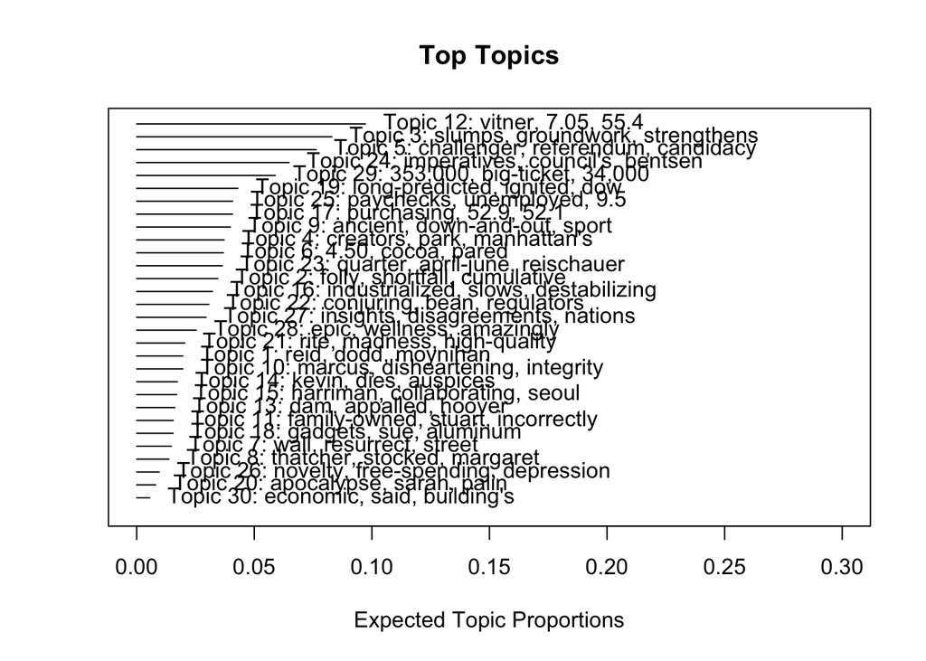

```r
load("../backup/stm-small-output.Rdata")

# summary
plot(stm, type = "summary", xlim = c(0, .3))
```

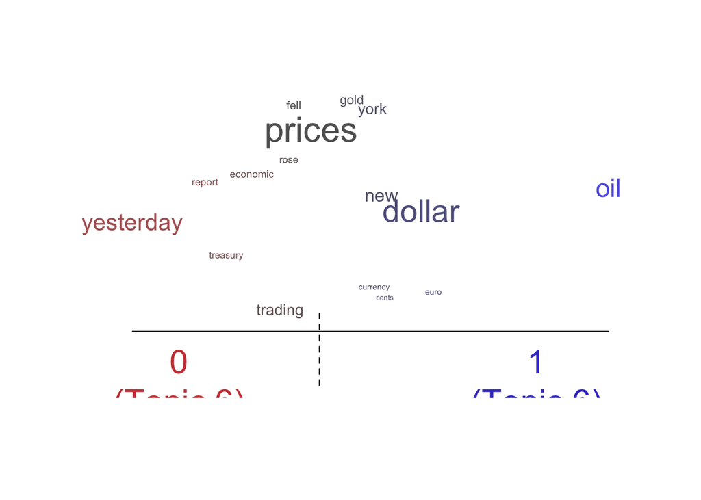

```r
# how topics are different under republican (TRUE) presidents
plot(stm, type = "perspectives", topics = 6)
```

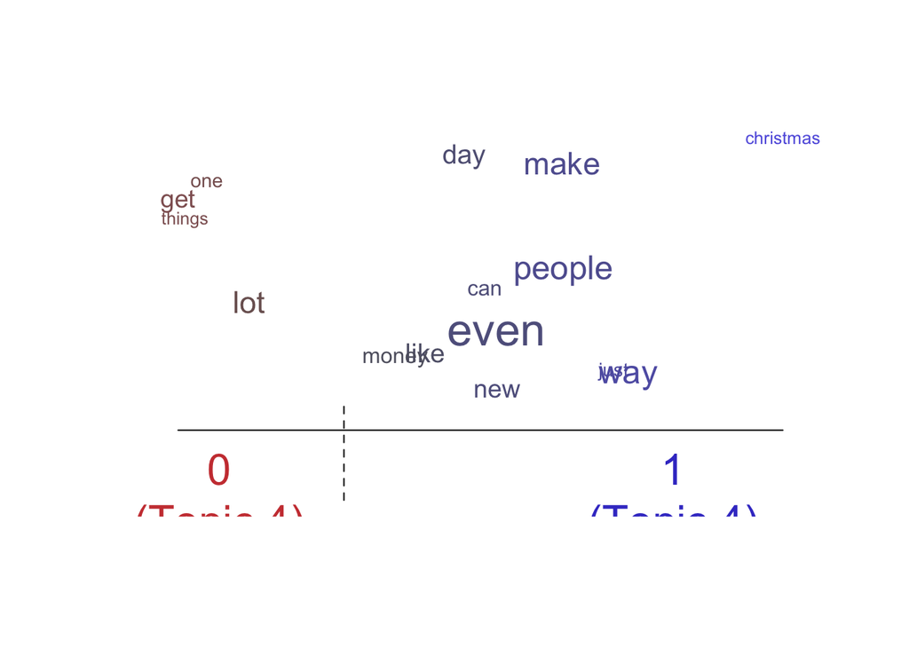

```r
plot(stm, type = "perspectives", topics = 4)
```

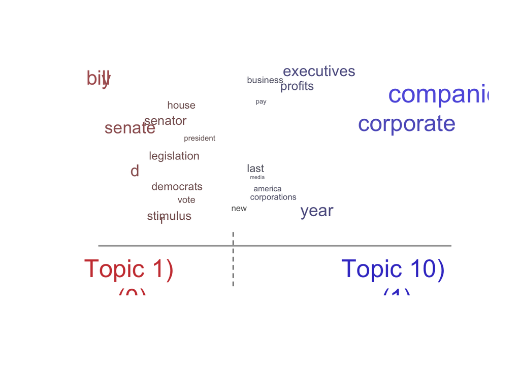

```r
# we can also compare specific topics
plot(stm, type = "perspectives", topics = c(1,10))
```

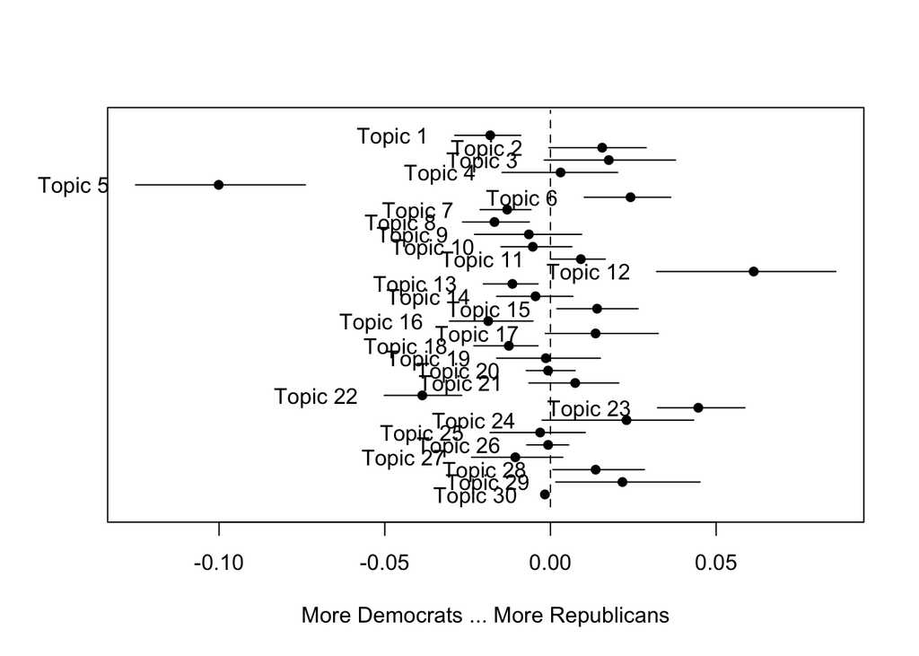

```r
# prevalence over time
est <- estimateEffect(~s(year)+repub,
    stm, uncertainty = "None", meta=meta)

plot(est, covariate="repub", topics=1:30,
    model=stm, method="difference",
    cov.value1=0, cov.value2=1,
    xlab = "More Democrats ... More Republicans",
    labeltype="custom", custom.labels=paste("Topic", 1:30))
```

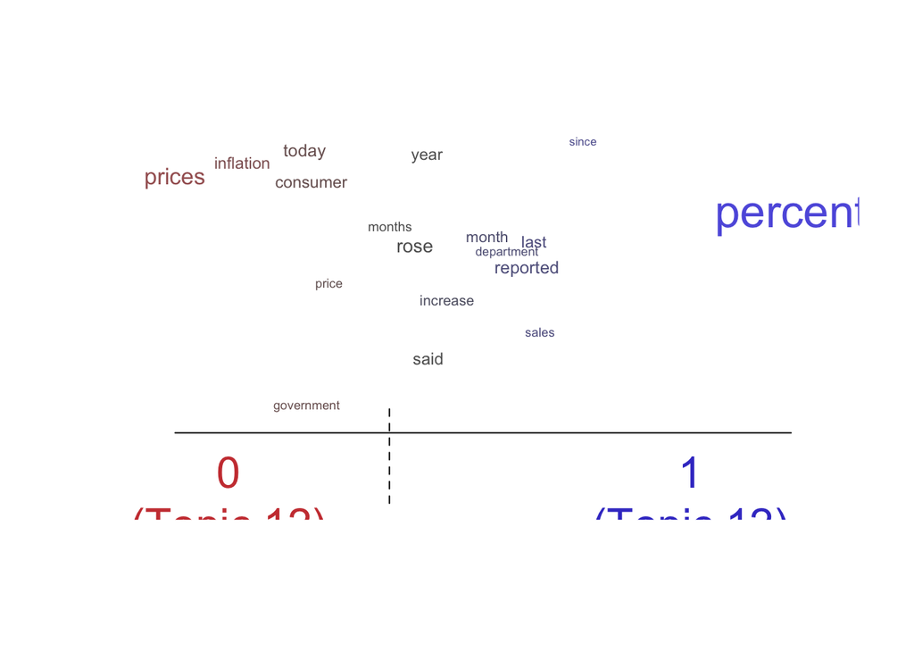

```r
plot(stm, type = "perspectives", topics = 12)
```

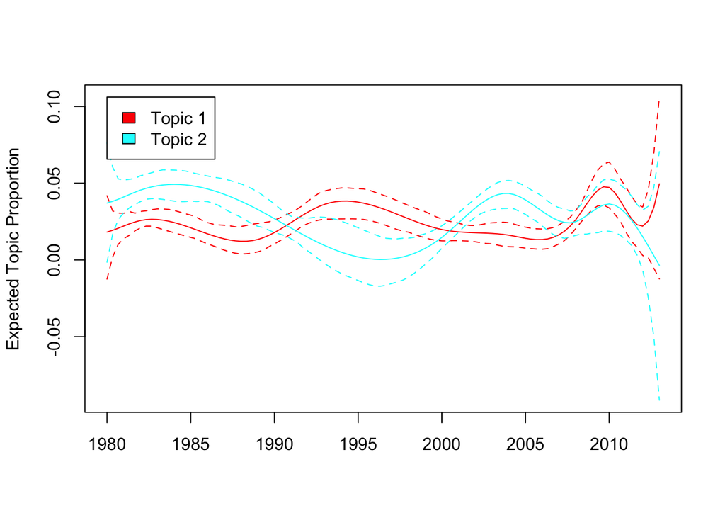

```r
plot(est, "year", method="continuous", topics=1:2)
```

## Choosing the number of topics

Finally, this is the code to generate the figure in the slides. Many moving parts here…

```r
require(cvTools)
cvLDA <- function(Ntopics,dtm,K=5) {
  folds<-cvFolds(nrow(dtm),K,1)
  perplex <- rep(NA,K)
  llk <- rep(NA,K)
  for(i in unique(folds$which)){
    cat(i, " ")
    which.test <- folds$subsets[folds$which==i]
    which.train <- {1:nrow(dtm)}[-which.test]
    dtm.train <- dtm[which.train,]
    dtm.test <- dtm[which.test,]
    lda.fit <- LDA(dtm.train, k=Ntopics, method="Gibbs",
        control=list(verbose=50L, iter=100))
    perplex[i] <- perplexity(lda.fit, convert(dtm.test, to="topicmodels"))
    llk[i] <- logLik(lda.fit)
  }
  return(list(K=Ntopics,perplexity=perplex,logLik=llk))
}
```

```r
K <- c(20, 30, 40, 50, 60, 70)

results <- list()

i = 1
for (k in K){
    cat("\n\n\n##########\n ", k, "topics", "\n")
    res <- cvLDA(k, cdfm)
    results[[i]] <- res
    i = i + 1
}
```

```
##
##
##
## ##########
##   20 topics
## 1  K = 20; V = 11492; M = 4000
## Sampling 100 iterations!
## Iteration 50 ...
## Iteration 100 ...
## Gibbs sampling completed!
## K = 20; V = 11492; M = 1000
## Sampling 100 iterations!
## Iteration 50 ...
## Iteration 100 ...
## Gibbs sampling completed!
## 2  K = 20; V = 11492; M = 4000
## Sampling 100 iterations!
## Iteration 50 ...
## Iteration 100 ...
## Gibbs sampling completed!
## K = 20; V = 11492; M = 1000
## Sampling 100 iterations!
## Iteration 50 ...
## Iteration 100 ...
## Gibbs sampling completed!
## 3  K = 20; V = 11492; M = 4000
## Sampling 100 iterations!
## Iteration 50 ...
## Iteration 100 ...
## Gibbs sampling completed!
## K = 20; V = 11492; M = 1000
## Sampling 100 iterations!
## Iteration 50 ...
## Iteration 100 ...
## Gibbs sampling completed!
## 4  K = 20; V = 11492; M = 4000
## Sampling 100 iterations!
## Iteration 50 ...
## Iteration 100 ...
## Gibbs sampling completed!
```

[output cut: 275 more lines]

```
## K = 70; V = 11492; M = 1000
## Sampling 100 iterations!
## Iteration 50 ...
## Iteration 100 ...
## Gibbs sampling completed!
## 5  K = 70; V = 11492; M = 4000
## Sampling 100 iterations!
## Iteration 50 ...
## Iteration 100 ...
## Gibbs sampling completed!
## K = 70; V = 11492; M = 1000
## Sampling 100 iterations!
## Iteration 50 ...
## Iteration 100 ...
## Gibbs sampling completed!
```

```r
## plot
df <- data.frame(
    k = rep(K, each=5),
    perp =  unlist(lapply(results, '[[', 'perplexity')),
    loglk = unlist(lapply(results, '[[', 'logLik')),
    stringsAsFactors=F)

min(df$perp)
```

```
## [1] 1878.043
```

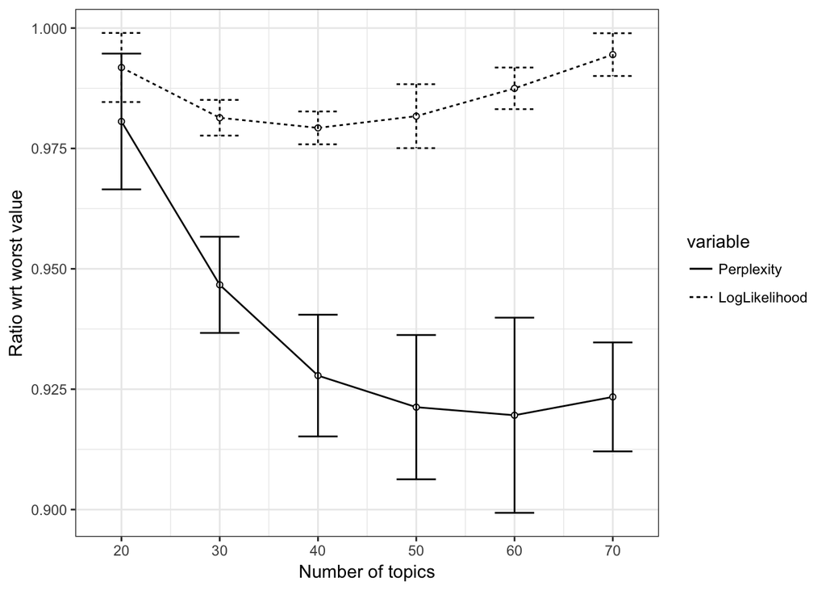

```r
df$ratio_perp <- df$perp / max(df$perp)
df$ratio_lk <- df$loglk / min(df$loglk)

df <- data.frame(cbind(
    aggregate(df$ratio_perp, by=list(df$k), FUN=mean),
    aggregate(df$ratio_perp, by=list(df$k), FUN=sd)$x,
    aggregate(df$ratio_lk, by=list(df$k), FUN=mean)$x,
    aggregate(df$ratio_lk, by=list(df$k), FUN=sd)$x),
    stringsAsFactors=F)
names(df) <- c("k", "ratio_perp", "sd_perp", "ratio_lk", "sd_lk")
library(reshape)
pd <- melt(df[,c("k","ratio_perp", "ratio_lk")], id.vars="k")
pd2 <- melt(df[,c("k","sd_perp", "sd_lk")], id.vars="k")
pd$sd <- pd2$value
levels(pd$variable) <- c("Perplexity", "LogLikelihood")

library(ggplot2)
library(grid)

p <- ggplot(pd, aes(x=k, y=value, linetype=variable))
pq <- p + geom_line() + geom_point(aes(shape=variable),
        fill="white", shape=21, size=1.40) +
    geom_errorbar(aes(ymax=value+sd, ymin=value-sd), width=4) +
    scale_y_continuous("Ratio wrt worst value") +
    scale_x_continuous("Number of topics",
        breaks=K) +
    theme_bw()
pq
```